# Airline Performance Analysis

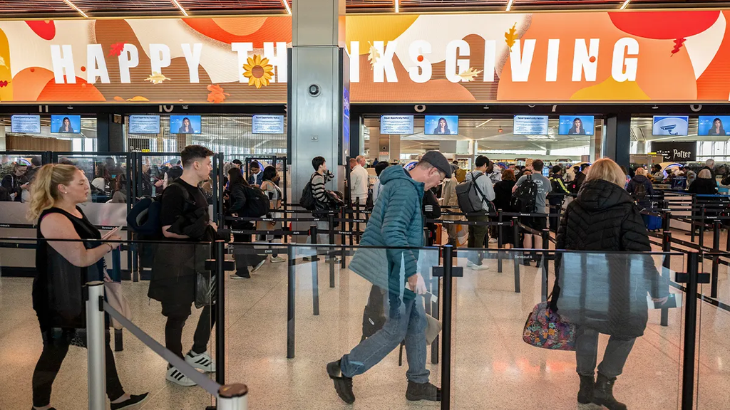

## Project Objective

This project examines U.S. airline performance during November 2023, using data from the Bureau of Transportation Statistics. The goal is to evaluate how airlines and airports operated during the start of the busy holiday travel season—focusing on delays, cancellations, and day-to-day flight behavior.

## Key Questions

1. Which airlines and airports demonstrated the strongest reliability?
2. Where did delays or cancellations cluster, and which carriers were most affected?
3. How did broader operational patterns such as weekday demand or holiday travel surges—shape overall performance?

## Author

Ishika is a first-year Master’s student in Data Science and Analytics at Georgetown University. This project, completed for DSAN 6300 (Database Systems and SQL), analyzes U.S. airline performance during November 2023 using SQL-generated datasets from the Bureau of Transportation Statistics. All analysis was conducted in Python and presented through a Quarto website, with a narrative storyline designed to highlight key findings and insights. Her academic interests include data visualization, transportation analytics, and storytelling with data.